# Entregable 2 Proyecto Integrador

Héctor Robles Villareal A01634105, Sophia Fernanda Valencia Bautista A01745091 y Diego Sú Gómez A01620476

29 de abril de 2021

##Escenario 1: Analizar las secuencias de SARS-CoV-2 reportadas en los 20 países con más casos reportados. Y puedes tratar de responder a la pregunta: ¿Son muy diferentes las variantes entre cada país? ¿Es diferente el SARS-CoV-2 entre las diferentes poblaciones: Asiática, Hispana, Europea o Africana?

Investigación:

¿Cuáles son los virus “similares” a SARS-CoV-2 en el mundo? Obtén tus referencias de PUBMED. SARS-CoV y MERS-CoV. Las secuencias de SARS-CoV-2 junto con las otras dos, además de su capacidad para enfermar al huésped (patogenicidad) que en el que se encuentra son similares de acuerdo a los estudios realizados.  
Rabaan, A & Al-Ahmed, S & Haque, S & Sah, R & Tiwari, R & Malik, Y & Dhama, K & Yatoo, M & Bonilla, K & Rodriguez, A.(2020). SARS-CoV-2, SARS-CoV, and MERS-COV: A comparative overview. PubMed. Recuperado de https://pubmed.ncbi.nlm.nih.gov/32275259/

¿Cuáles son los coronavirus reportados en otras especies que pueden ser cercanos al genoma de SARS-CoV-2? Incluye de qué especies son y menciona las referencias de los artículos consultados en PUBMED.

De murciélago: HCoV-NL63, HCov-229E, SARS-Cov, MERS-Cov De roedores: HCoV- OC43, HCOV-HKU1 En específico, se han detectado dos especies que son los posibles huéspedes de coronavirus cercanos al genoma del SARS-CoV-2, los murciélagos de herradura de la especie Rhinolophus affinis y los pangolines Manis javanica.

Ye,W & Yuan,S & Yuen,K & Fung,S & Chan,C & Jin,D. (2020). Zoonotic origins of human coronaviruses. Pubmed. Recuperado de https://pubmed.ncbi.nlm.nih.gov/32226286/

Vale,B & Lopes, A & Conceição, M & Silvestre, M & Cardoso, L & Coelho, A. (2021). Bats, pangolins, minks and other animals - villains or victims of SARS-CoV-2?. Pubmed. Recuperado de https://pubmed.ncbi.nlm.nih.gov/33464439/

Moneim, A & Abdelwhab, A. (2020). Evidence for SARS-CoV-2 Infection of Animal Hosts. PubMed. Recuperado de https://pubmed.ncbi.nlm.nih.gov/32629960/

En relación con la situación actual reflexiona, ¿qué propondrías que se deba hacer durante la contingencia del SARS-CoV-2 en comunidades de bajos recursos? Si tu vivieras en una situación de escasos recursos, ¿qué harías? Justifica tu respuesta.

En caso de que tuviéramos que actuar en una comunidad de escasos recursos durante la contingencia del SARS-COV-2, lo que haríamos sería, además del uso obligatorio de cubrebocas, priorizar el aislamiento de las personas, es decir evitar aglomeraciones y reuniones innecesarias, únicamente permitir que haya gente en los hospitales, ya que así evitaríamos al máximo los contagios innecesarios. Por otro lado, también estableceríamos restricciones muy estrictas, que limiten el número de personas que salgan a comprar comida/ agua, es decir, que sea un miembro por familia y que ese miembro sea el que menor riesgo tenga de contagiarse gravemente ( Jóvenes, adultos). Otra cosa que haríamos sería buscar voluntarios que pudieran trabajar en los centros médicos y que no sean personas de riesgo, para también ahí tratar de reducir la probabilidad de que haya decesos. En conclusión, lo principal que se haría en este caso sería limitar los espacios públicos y evitar las salidas de personas que no tengan que hacerlo de forma esencial, además de procurar que las personas expuestas tengan el menor riesgo posible.

##Cargar librerías

```r
library(Biostrings)
library(seqinr)
library(adegenet)
library(ape)
library(ggtree)
library(DECIPHER)
library(viridis)
```

```r
library(ggplot2)
```

##Leer todas las secuencias de los países junto con el dataframe que los organiza

```r
df <- read.csv("Evidencia02.csv", header = TRUE)
df
```

```
##               País ID.Acceso
## 1              USA  MW965797
## 2           Brasil  MW592707
## 3           México  MW884219
## 4            India  MW927136
## 5      Reino Unido  OA976392
## 6           Italia  MW852494
## 7            Rusia  MW741552
## 8          Francia  LR881474
## 9         Alemania  MW822592
## 10          España  MW976780
## 11        Colombia  MT470219
## 12            Irán  MW898809
## 13         Polonia  HG994158
## 14       Argentina  MW633891
```

[output cut: 69 more lines]

```r
EUA <- read.GenBank(df[1,2],as.character = TRUE)
Brasil <- read.GenBank(df[2,2],as.character = TRUE)
Mexico <-read.GenBank(df[3,2],as.character = TRUE)
India <-read.GenBank(df[4,2],as.character = TRUE)
UK <-read.GenBank(df[5,2],as.character = TRUE)
Italia <-read.GenBank(df[6,2],as.character = TRUE)
Rusia <-read.GenBank(df[7,2],as.character = TRUE)
Francia <-read.GenBank(df[8,2],as.character = TRUE)
Alemania <-read.GenBank(df[9,2],as.character = TRUE)
Espana <- read.GenBank(df[10,2],as.character = TRUE)
Colombia <- read.GenBank(df[11,2],as.character = TRUE)
Iran <- read.GenBank(df[12,2],as.character = TRUE)
Polonia <- read.GenBank(df[13,2],as.character = TRUE)
Argentina <- read.GenBank(df[14,2],as.character = TRUE)
Peru <- read.GenBank(df[15,2],as.character = TRUE)
Sudafrica <- read.GenBank(df[16,2],as.character = TRUE)
Indonesia <- read.GenBank(df[17,2],as.character = TRUE)
RepCheca <- read.GenBank(df[18,2],as.character = TRUE)
Turquia <- read.GenBank(df[19,2],as.character = TRUE)
Romania <- read.GenBank(df[20,2],as.character = TRUE)
```

#Calcular la longitud de las secuencias

```r
dftUSA <- as.data.frame(count(EUA$MW965797, wordsize = 1))
dftBrasil <- as.data.frame(count(Brasil$MW592707, wordsize = 1))
dftMexico <- as.data.frame(count(Mexico$MW884219, wordsize = 1))
dftIndia <- as.data.frame(count(India$MW927136, wordsize = 1))
dftReinoU <- as.data.frame(count(UK$OA976392, wordsize = 1))
dftItalia <- as.data.frame(count(Italia$MW852494, wordsize = 1))
dftRusia <- as.data.frame(count(Rusia$MW741552, wordsize = 1))
dftFrancia <- as.data.frame(count(Francia$LR881474, wordsize = 1))
dftAlemania <- as.data.frame(count(Alemania$MW822592, wordsize = 1))
dftEspana <- as.data.frame(count(Espana$MW976780, wordsize = 1))
dftColombia <- as.data.frame(count(Colombia$MT470219, wordsize = 1))
dftIran <- as.data.frame(count(Iran$MW898809, wordsize = 1))
dftPolonia <- as.data.frame(count(Polonia$HG994158, wordsize = 1))
dftArgentina <- as.data.frame(count(Argentina$MW633891, wordsize = 1))
dftPeru <- as.data.frame(count(Peru$MW938089, wordsize = 1))
dftSudafrica <- as.data.frame(count(Sudafrica$MW981442, wordsize = 1))
dftIndonesia <- as.data.frame(count(Indonesia$MZ026853, wordsize = 1))
dftRepCheca <- as.data.frame(count(RepCheca$MT534285, wordsize = 1))
dftTurquia <- as.data.frame(count(Turquia$MW308549, wordsize = 1))
dftRomania <- as.data.frame(count(Romania$MW255830, wordsize = 1))

longitud = function(dataframe){
  tamanio <- 0
  for (i in 1:4){
    tamanio <- dataframe[i,2] + tamanio
  }
  return(tamanio)
}
cat("Tamaño de la secuencia de COVID de USA:",longitud(dftUSA),"\n")
```

```
## Tamaño de la secuencia de COVID de USA: 28718
```

```r
cat("Tamaño de la secuencia de COVID de Brasil :",longitud(dftBrasil),"\n")
```

```
## Tamaño de la secuencia de COVID de Brasil : 29862
```

```r
cat("Tamaño de la secuencia de COVID de Mexico:",longitud(dftMexico),"\n")
```

```
## Tamaño de la secuencia de COVID de Mexico: 29886
```

```r
cat("Tamaño de la secuencia de COVID de India:",longitud(dftIndia),"\n")
```

```
## Tamaño de la secuencia de COVID de India: 29866
```

```r
cat("Tamaño de la secuencia de COVID de Reino Unido:",longitud(dftReinoU),"\n")
```

```
## Tamaño de la secuencia de COVID de Reino Unido: 29782
```

```r
cat("Tamaño de la secuencia de COVID de Italia:",longitud(dftItalia),"\n")
```

```
## Tamaño de la secuencia de COVID de Italia: 29666
```

```r
cat("Tamaño de la secuencia de COVID de Rusia:",longitud(dftRusia),"\n")
```

```
## Tamaño de la secuencia de COVID de Rusia: 29903
```

```r
cat("Tamaño de la secuencia de COVID de Francia:",longitud(dftFrancia),"\n")
```

```
## Tamaño de la secuencia de COVID de Francia: 29703
```

```r
cat("Tamaño de la secuencia de COVID de Alemania:",longitud(dftAlemania),"\n")
```

```
## Tamaño de la secuencia de COVID de Alemania: 29753
```

```r
cat("Tamaño de la secuencia de COVID de España:",longitud(dftEspana),"\n")
```

```
## Tamaño de la secuencia de COVID de España: 29763
```

```r
cat("Tamaño de la secuencia de COVID de Colombia:",longitud(dftColombia),"\n")
```

```
## Tamaño de la secuencia de COVID de Colombia: 29903
```

```r
cat("Tamaño de la secuencia de COVID de Irán:",longitud(dftIran),"\n")
```

```
## Tamaño de la secuencia de COVID de Irán: 29736
```

```r
cat("Tamaño de la secuencia de COVID de Polonia:",longitud(dftPolonia),"\n")
```

```
## Tamaño de la secuencia de COVID de Polonia: 29754
```

```r
cat("Tamaño de la secuencia de COVID de Argentina:",longitud(dftArgentina),"\n")
```

```
## Tamaño de la secuencia de COVID de Argentina: 28566
```

```r
cat("Tamaño de la secuencia de COVID de Perú:",longitud(dftPeru),"\n")
```

```
## Tamaño de la secuencia de COVID de Perú: 29841
```

```r
cat("Tamaño de la secuencia de COVID de Sudáfrica:",longitud(dftSudafrica),"\n")
```

```
## Tamaño de la secuencia de COVID de Sudáfrica: 29831
```

```r
cat("Tamaño de la secuencia de COVID de Indonesia:",longitud(dftIndonesia),"\n")
```

```
## Tamaño de la secuencia de COVID de Indonesia: 29707
```

```r
cat("Tamaño de la secuencia de COVID de República Checa:",longitud(dftRepCheca),"\n")
```

```
## Tamaño de la secuencia de COVID de República Checa: 29781
```

```r
cat("Tamaño de la secuencia de COVID de Turquía:",longitud(dftTurquia),"\n")
```

```
## Tamaño de la secuencia de COVID de Turquía: 29813
```

```r
cat("Tamaño de la secuencia de COVID de Romania:",longitud(dftRomania),"\n")
```

```
## Tamaño de la secuencia de COVID de Romania: 29590
```

##Comparación de bases de ADN que tiene el virus

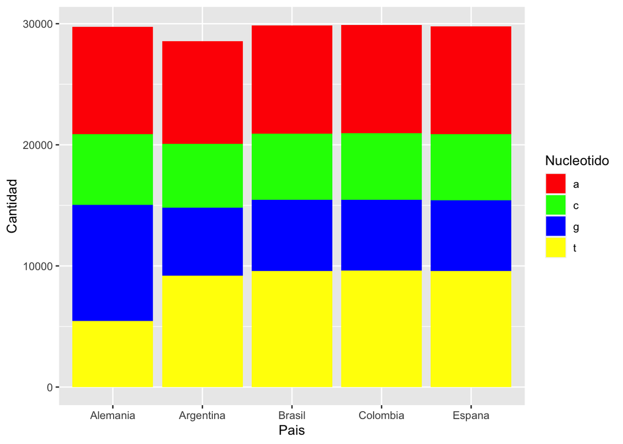

```r
Nucleotidos <- read.csv("Nucleotidos.csv")
dfuno <- as.data.frame(Nucleotidos[1:20,])
dfdos <- as.data.frame(Nucleotidos[21:40,])
dftres <- as.data.frame(Nucleotidos[41:60,])
dfcuatro <- as.data.frame(Nucleotidos[61:80,])
ggplot(data = dfuno, aes(x=Pais,y=Cantidad,fill=Nucleotido))+geom_bar(stat="identity")+scale_fill_manual(values = c("a" = "red", "c" = "green", "g" = "blue", "t"=    "yellow"))
```

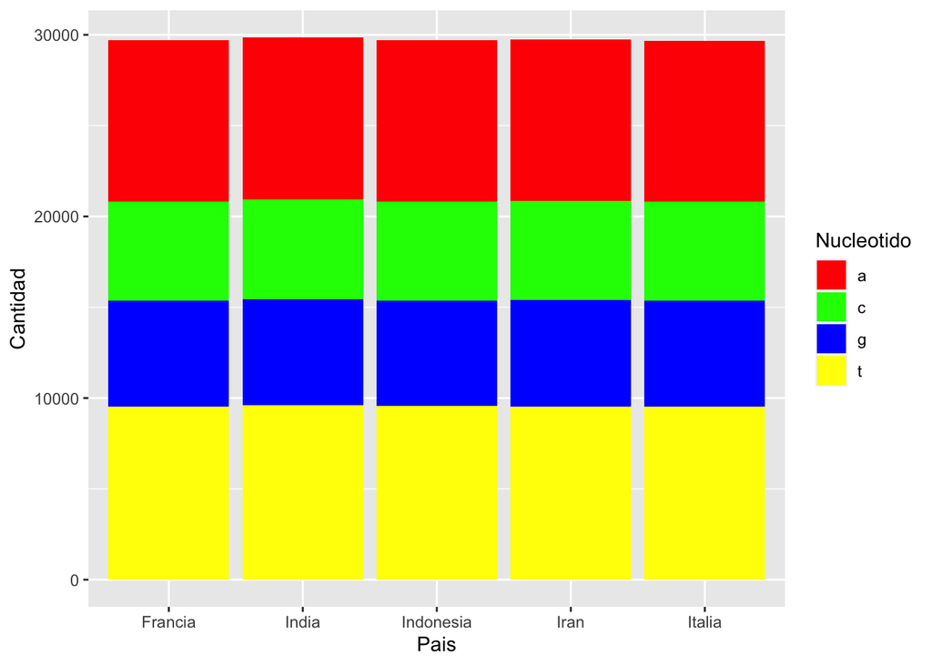

```r
ggplot(data = dfdos, aes(x=Pais,y=Cantidad,fill=Nucleotido))+geom_bar(stat="identity")+scale_fill_manual(values = c("a" = "red", "c" = "green", "g" = "blue", "t"=    "yellow"))
```

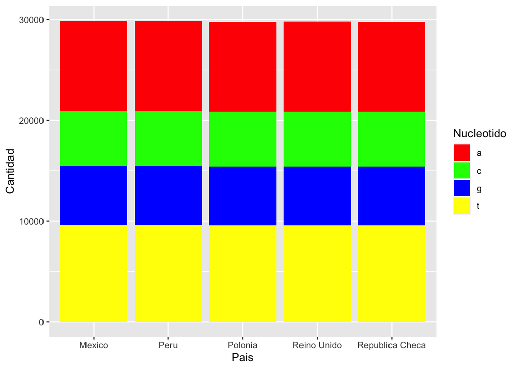

```r
ggplot(data = dftres, aes(x=Pais,y=Cantidad,fill=Nucleotido))+geom_bar(stat="identity")+scale_fill_manual(values = c("a" = "red", "c" = "green", "g" = "blue", "t"=    "yellow"))
```

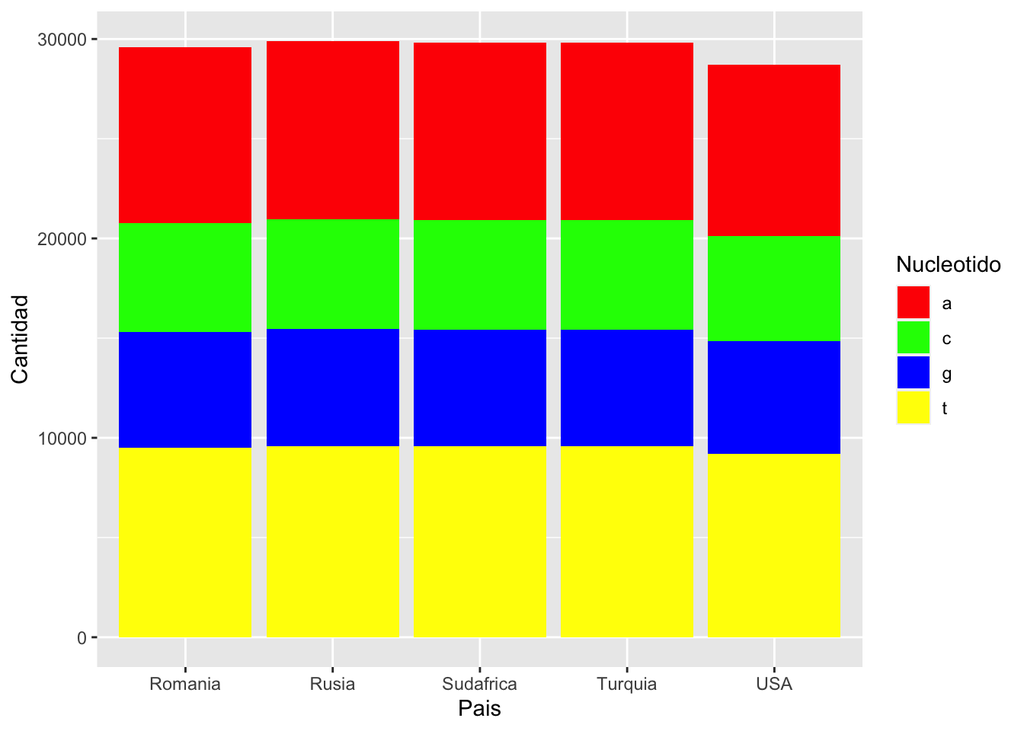

```r
ggplot(data = dfcuatro, aes(x=Pais,y=Cantidad,fill=Nucleotido))+geom_bar(stat="identity")+scale_fill_manual(values = c("a" = "red", "c" = "green", "g" = "blue", "t"=    "yellow"))
```

```r
ids <- c()
paises <-c()
for (i in 1:20){
  ids <- append(ids,df[i,2])
  paises <- append(paises,df[i,1])
}
paises
```

```
##  [1] "USA"             "Brasil"          "México"          "India"
##  [5] "Reino Unido"     "Italia"          "Rusia"           "Francia"
##  [9] "Alemania"        "España"          "Colombia"        "Irán"
## [13] "Polonia"         "Argentina"       "Perú"            "Sudáfrica"
## [17] "Indonesia"       "República Checa" "Turquía"         "Romania"
```

```r
ids
```

```
##  [1] "MW965797" "MW592707" "MW884219" "MW927136" "OA976392" "MW852494"
##  [7] "MW741552" "LR881474" "MW822592" "MW976780" "MT470219" "MW898809"
## [13] "HG994158" "MW633891" "MW938089" "MW981442" "MZ026853" "MT534285"
## [19] "MW308549" "MW255830"
```

```r
dfViruses <- data.frame(id = ids, pais = paises)
dfViruses
```

```
##          id            pais
## 1  MW965797             USA
## 2  MW592707          Brasil
## 3  MW884219          México
## 4  MW927136           India
## 5  OA976392     Reino Unido
## 6  MW852494          Italia
## 7  MW741552           Rusia
## 8  LR881474         Francia
## 9  MW822592        Alemania
## 10 MW976780          España
## 11 MT470219        Colombia
## 12 MW898809            Irán
## 13 HG994158         Polonia
## 14 MW633891       Argentina
## 15 MW938089            Perú
## 16 MW981442       Sudáfrica
## 17 MZ026853       Indonesia
## 18 MT534285 República Checa
## 19 MW308549         Turquía
## 20 MW255830         Romania
```

```r
virus_secuencias <- read.GenBank(dfViruses[,1])
virus_secuencias
```

```
## 20 DNA sequences in binary format stored in a list.
##
## Mean sequence length: 29811.95
##    Shortest sequence: 29666
##     Longest sequence: 29903
##
## Labels:
## MW965797
## MW592707
## MW884219
## MW927136
## OA976392
## MW852494
## ...
##
## Base composition:
##     a     c     g     t
## 0.299 0.184 0.196 0.321
## (Total: 596.24 kb)
```

```r
write.dna(virus_secuencias,
          file ="virus_seqs.fasta2", format = "fasta", append =
FALSE, nbcol = 6, colsep = "", colw = 40)
```

```r
virus_seq_no_alineadas <- readDNAStringSet("virus_seqs.fasta2", format = "fasta")
virus_seq_no_alineadas
```

```
## DNAStringSet object of length 20:
##      width seq                                              names
##  [1] 29689 AGATCTGTTCTCTAAACGAACTT...AGTACGATCGAGTGTACAGTGA MW965797
##  [2] 29862 TACCTTCCCAGGTAACAAACCAA...GCTTCTTAGGAGAATGACAAAA MW592707
##  [3] 29895 TTTATACCTTCCCAGGTAACAAA...AAAAAAAAAAAAAAAAAAAAAA MW884219
##  [4] 29866 ATTAAAGGTTTATACCTTCCCAG...TTTTAATAGCTTCTTAGGAGAA MW927136
##  [5] 29903 NNNNNNNNNNNNNNNNNNNNNNN...NNNNNNNNNNNNNNNNNNNNNN OA976392
##  ...   ... ...
## [16] 29848 AACTTTCGATCTCTTGTAGATCT...AAAAAAAAAAAAAAAAAAAAAA MW981442
## [17] 29709 AGATCTGTTCTCTAAACGAACTT...GTACGATCGAGTGTACAGTGAA MZ026853
## [18] 29838 AGACGGCGGTTCGGTTTCTTGTA...AATAGCTTCTTAGGAGAATGAC MT534285
## [19] 29813 CAACCAACTTTCGATCTCTTGTA...AGTAGTTCTATCCCCATGTGAT MW308549
## [20] 29840 AACCAACCAACTTTCGATCTCTT...TTTTAATAGCTTCTTAGGAGAA MW255830
```

```r
virus_seq_no_alineadas <- OrientNucleotides(virus_seq_no_alineadas)
```

```
## ========================================================================================================================================================================================================
##
## Time difference of 0.35 secs
```

```r
virus_seq_alineadas <- AlignSeqs(virus_seq_no_alineadas)
```

[output not shown]

```r
BrowseSeqs(virus_seq_alineadas, highlight = 0)
```

```r
writeXStringSet(virus_seq_alineadas, file = "virus_align_seq.fasta2")
```

```r
virus_aligned <- read.alignment("virus_align_seq.fasta2", format = "fasta")
```

```r
matriz_distancias <- dist.alignment(virus_aligned, matrix = "similarity")
matriz_distancias
```

```
##             MW965797    MW592707    MW884219    MW927136    OA976392
## MW592707 0.035894158
## MW884219 0.040022279 0.025227999
## MW927136 0.035405779 0.020867500 0.027147174
## OA976392 0.035894158 0.021681388 0.027789900 0.019218497
## MW852494 0.030699742 0.036722911 0.039378280 0.035315988 0.035818435
## MW741552 0.036375980 0.022412287 0.028338165 0.020044817 0.020892709
## LR881474 0.032346823 0.020920474 0.026589458 0.018348469 0.019244037
## MW822592 0.039156881 0.030124268 0.033804466 0.029561148 0.030124774
## MW976780 0.044552071 0.034778664 0.038883729 0.033298036 0.033798786
## MT470219 0.032855172 0.021652327 0.027741505 0.019191451 0.020073065
## MW898809 0.042602919 0.034307790 0.038466712 0.032804522 0.032818873
## HG994158 0.035970644 0.022452926 0.027803908 0.020082508 0.020911675
## MW633891 0.038141971 0.028985507 0.033469581 0.027113459 0.027751510
## MW938089 0.042191287 0.029523465 0.034251970 0.028945288 0.029546752
## MW981442 0.040937991 0.032768177 0.036158106 0.032255358 0.032789088
## MZ026853 0.036423573 0.026587668 0.031778342 0.023207619 0.025289917
## MT534285 0.034483362 0.029547248 0.034287042 0.027792233 0.022463876
## MW308549 0.037847252 0.028957907 0.033770432 0.027164924 0.027789900
## MW255830 0.037547184 0.023970329 0.029646966 0.021752719 0.022537161
##             MW852494    MW741552    LR881474    MW822592    MW976780
## MW592707
## MW884219
## MW927136
## OA976392
## MW852494
## MW741552 0.036257913
## LR881474 0.031850257 0.020099741
## MW822592 0.038115625 0.030677053 0.023218955
## MW976780 0.044632184 0.034292225 0.033342316 0.039752445
## MT470219 0.032843202 0.020850395 0.005802295 0.023903367 0.033798786
## MW898809 0.041932811 0.033814127 0.029621941 0.037617740 0.042646605
## HG994158 0.035851131 0.021691588 0.020102449 0.030702345 0.034323377
## MW633891 0.038416912 0.028375218 0.019638756 0.030184398 0.038356980
## MW938089 0.041462510 0.030080825 0.029011477 0.036204864 0.040158942
## MW981442 0.039829522 0.032236430 0.026597519 0.019227860 0.041805074
## MZ026853 0.036290958 0.025946907 0.018361456 0.029598975 0.037162204
## MT534285 0.038565405 0.028973460 0.011615742 0.025951712 0.035292203
## MW308549 0.037642479 0.028372838 0.020920474 0.031753766 0.038883729
## MW255830 0.037347590 0.023254635 0.021802146 0.031888019 0.035407412
```

[output cut: 25 more lines]

```
## MW852494
## MW741552
## LR881474
## MW822592
## MW976780
## MT470219
## MW898809
## HG994158
## MW633891
## MW938089
## MW981442
## MZ026853 0.032313430
## MT534285 0.032285169 0.021729597
## MW308549 0.034276682 0.025289917 0.030122749
## MW255830 0.034417924 0.027328117 0.030239334 0.029080090
```

```r
virus_str_filogenetico <- njs(matriz_distancias)
virus_str_filogenetico
```

```
##
## Phylogenetic tree with 20 tips and 18 internal nodes.
##
## Tip labels:
##   MW965797, MW592707, MW884219, MW927136, OA976392, MW852494, ...
##
## Unrooted; includes branch lengths.
```

```r
class(virus_str_filogenetico)
```

```
## [1] "phylo"
```

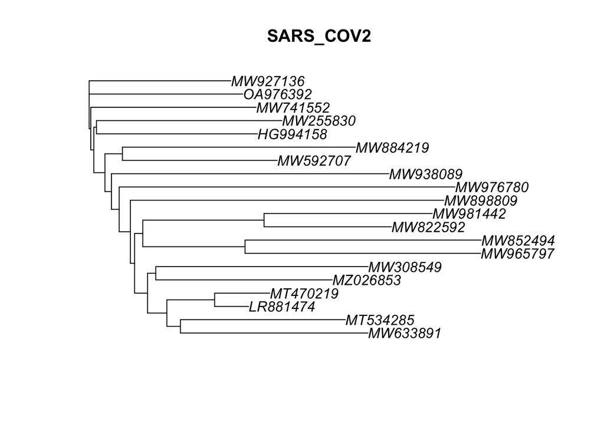

```r
virus_plot <- ladderize(virus_str_filogenetico)
plot(virus_plot)
title("SARS_COV2")
```